# Risk Factor Analysis

## Outcome Variable

**Outcome Variable:** ever_wasted

## Predictor Variables

**Intervention Variable:** mwtkg

**Adjustment Set:**

- arm
- W_mage
- meducyrs
- feducyrs
- W_nchldlt5
- brthmon
- W_parity
- delta_W_mage
- delta_meducyrs
- delta_feducyrs
- delta_W_nchldlt5
- delta_brthmon
- delta_W_parity

## Stratifying Variables

The analysis was stratified on these variable(s):

- agecat
- studyid
- country

## Data Summary

| agecat | studyid | country | mwtkg | ever_wasted | n_cell | n |
| --- | --- | --- | --- | --- | --- | --- |
| 0-24 months | iLiNS-Zinc | BURKINA FASO | >=58 kg | 0 | 764 | 3217 |
| 0-24 months | iLiNS-Zinc | BURKINA FASO | >=58 kg | 1 | 173 | 3217 |
| 0-24 months | iLiNS-Zinc | BURKINA FASO | <52 kg | 0 | 865 | 3217 |
| 0-24 months | iLiNS-Zinc | BURKINA FASO | <52 kg | 1 | 336 | 3217 |
| 0-24 months | iLiNS-Zinc | BURKINA FASO | [52-58) kg | 0 | 855 | 3217 |
| 0-24 months | iLiNS-Zinc | BURKINA FASO | [52-58) kg | 1 | 224 | 3217 |
| 0-24 months | JiVitA-3 | BANGLADESH | >=58 kg | 0 | 506 | 26925 |
| 0-24 months | JiVitA-3 | BANGLADESH | >=58 kg | 1 | 155 | 26925 |
| 0-24 months | JiVitA-3 | BANGLADESH | <52 kg | 0 | 18166 | 26925 |
| 0-24 months | JiVitA-3 | BANGLADESH | <52 kg | 1 | 6340 | 26925 |
| 0-24 months | JiVitA-3 | BANGLADESH | [52-58) kg | 0 | 1306 | 26925 |
| 0-24 months | JiVitA-3 | BANGLADESH | [52-58) kg | 1 | 452 | 26925 |
| 0-24 months | LCNI-5 | MALAWI | >=58 kg | 0 | 109 | 838 |
| 0-24 months | LCNI-5 | MALAWI | >=58 kg | 1 | 5 | 838 |
| 0-24 months | LCNI-5 | MALAWI | <52 kg | 0 | 457 | 838 |
| 0-24 months | LCNI-5 | MALAWI | <52 kg | 1 | 47 | 838 |
| 0-24 months | LCNI-5 | MALAWI | [52-58) kg | 0 | 206 | 838 |
| 0-24 months | LCNI-5 | MALAWI | [52-58) kg | 1 | 14 | 838 |
| 0-24 months | MAL-ED | BANGLADESH | >=58 kg | 0 | 39 | 254 |
| 0-24 months | MAL-ED | BANGLADESH | >=58 kg | 1 | 9 | 254 |
| 0-24 months | MAL-ED | BANGLADESH | <52 kg | 0 | 97 | 254 |
| 0-24 months | MAL-ED | BANGLADESH | <52 kg | 1 | 65 | 254 |
| 0-24 months | MAL-ED | BANGLADESH | [52-58) kg | 0 | 33 | 254 |
| 0-24 months | MAL-ED | BANGLADESH | [52-58) kg | 1 | 11 | 254 |
| 0-24 months | MAL-ED | BRAZIL | >=58 kg | 0 | 132 | 221 |
| 0-24 months | MAL-ED | BRAZIL | >=58 kg | 1 | 11 | 221 |
| 0-24 months | MAL-ED | BRAZIL | <52 kg | 0 | 40 | 221 |
| 0-24 months | MAL-ED | BRAZIL | <52 kg | 1 | 2 | 221 |
| 0-24 months | MAL-ED | BRAZIL | [52-58) kg | 0 | 30 | 221 |
| 0-24 months | MAL-ED | BRAZIL | [52-58) kg | 1 | 6 | 221 |

[output cut: 270 more lines]

The following strata were considered:

- agecat: 0-24 months, studyid: iLiNS-Zinc, country: BURKINA FASO
- agecat: 0-24 months, studyid: JiVitA-3, country: BANGLADESH
- agecat: 0-24 months, studyid: LCNI-5, country: MALAWI
- agecat: 0-24 months, studyid: MAL-ED, country: BANGLADESH
- agecat: 0-24 months, studyid: MAL-ED, country: BRAZIL
- agecat: 0-24 months, studyid: MAL-ED, country: INDIA
- agecat: 0-24 months, studyid: MAL-ED, country: NEPAL
- agecat: 0-24 months, studyid: MAL-ED, country: PERU
- agecat: 0-24 months, studyid: MAL-ED, country: SOUTH AFRICA
- agecat: 0-24 months, studyid: MAL-ED, country: TANZANIA, UNITED REPUBLIC OF
- agecat: 0-24 months, studyid: NIH-Birth, country: BANGLADESH
- agecat: 0-24 months, studyid: NIH-Crypto, country: BANGLADESH
- agecat: 0-24 months, studyid: PROBIT, country: BELARUS
- agecat: 0-24 months, studyid: PROVIDE, country: BANGLADESH
- agecat: 0-24 months, studyid: SAS-CompFeed, country: INDIA
- agecat: 0-24 months, studyid: TanzaniaChild2, country: TANZANIA, UNITED REPUBLIC OF
- agecat: 0-24 months, studyid: ZVITAMBO, country: ZIMBABWE
- agecat: 0-6 months, studyid: JiVitA-3, country: BANGLADESH
- agecat: 0-6 months, studyid: LCNI-5, country: MALAWI
- agecat: 0-6 months, studyid: MAL-ED, country: BANGLADESH
- agecat: 0-6 months, studyid: MAL-ED, country: BRAZIL
- agecat: 0-6 months, studyid: MAL-ED, country: INDIA
- agecat: 0-6 months, studyid: MAL-ED, country: NEPAL
- agecat: 0-6 months, studyid: MAL-ED, country: PERU
- agecat: 0-6 months, studyid: MAL-ED, country: SOUTH AFRICA
- agecat: 0-6 months, studyid: MAL-ED, country: TANZANIA, UNITED REPUBLIC OF
- agecat: 0-6 months, studyid: NIH-Birth, country: BANGLADESH
- agecat: 0-6 months, studyid: NIH-Crypto, country: BANGLADESH
- agecat: 0-6 months, studyid: PROBIT, country: BELARUS
- agecat: 0-6 months, studyid: PROVIDE, country: BANGLADESH
- agecat: 0-6 months, studyid: SAS-CompFeed, country: INDIA
- agecat: 0-6 months, studyid: TanzaniaChild2, country: TANZANIA, UNITED REPUBLIC OF
- agecat: 0-6 months, studyid: ZVITAMBO, country: ZIMBABWE
- agecat: 6-24 months, studyid: iLiNS-Zinc, country: BURKINA FASO
- agecat: 6-24 months, studyid: JiVitA-3, country: BANGLADESH
- agecat: 6-24 months, studyid: LCNI-5, country: MALAWI
- agecat: 6-24 months, studyid: MAL-ED, country: BANGLADESH
- agecat: 6-24 months, studyid: MAL-ED, country: BRAZIL
- agecat: 6-24 months, studyid: MAL-ED, country: INDIA
- agecat: 6-24 months, studyid: MAL-ED, country: NEPAL
- agecat: 6-24 months, studyid: MAL-ED, country: PERU
- agecat: 6-24 months, studyid: MAL-ED, country: SOUTH AFRICA
- agecat: 6-24 months, studyid: MAL-ED, country: TANZANIA, UNITED REPUBLIC OF
- agecat: 6-24 months, studyid: NIH-Birth, country: BANGLADESH
- agecat: 6-24 months, studyid: NIH-Crypto, country: BANGLADESH
- agecat: 6-24 months, studyid: PROBIT, country: BELARUS
- agecat: 6-24 months, studyid: PROVIDE, country: BANGLADESH
- agecat: 6-24 months, studyid: SAS-CompFeed, country: INDIA
- agecat: 6-24 months, studyid: TanzaniaChild2, country: TANZANIA, UNITED REPUBLIC OF
- agecat: 6-24 months, studyid: ZVITAMBO, country: ZIMBABWE

### Dropped Strata

Some strata were dropped due to rare outcomes:

- agecat: 0-24 months, studyid: MAL-ED, country: BRAZIL
- agecat: 0-6 months, studyid: LCNI-5, country: MALAWI
- agecat: 0-6 months, studyid: MAL-ED, country: BRAZIL
- agecat: 0-6 months, studyid: MAL-ED, country: PERU
- agecat: 0-6 months, studyid: MAL-ED, country: SOUTH AFRICA
- agecat: 0-6 months, studyid: MAL-ED, country: TANZANIA, UNITED REPUBLIC OF
- agecat: 6-24 months, studyid: MAL-ED, country: BANGLADESH
- agecat: 6-24 months, studyid: MAL-ED, country: BRAZIL
- agecat: 6-24 months, studyid: MAL-ED, country: INDIA
- agecat: 6-24 months, studyid: MAL-ED, country: PERU
- agecat: 6-24 months, studyid: MAL-ED, country: SOUTH AFRICA
- agecat: 6-24 months, studyid: MAL-ED, country: TANZANIA, UNITED REPUBLIC OF

## Methods Detail

We’re interested in the causal parameters $E[Y_a]$ for all values of $a \in \mathcal{A}$. These parameters represent the mean outcome if, possibly contrary to fact, we intervened to set all units to have $A=a$. Under the randomization and positivity assumptions, these are identified by the statistical parameters $\psi_a=E_W[E_{Y|A,W}(Y|A=a,W)]$. In addition, we’re interested in the mean of $Y$, $E[Y]$ under no intervention (the observed mean). We will estimate these parameters by using SuperLearner to fit the relevant likelihood factors – $E_{Y|A,W}(Y|A=a,W)$ and $p(A=a|W)$, and then updating our likelihood fit using a joint TMLE.

For unadjusted analyses ($W=\{\}$), initial likelihoods were estimated using Lrnr_glm to estimate the simple $E(Y|A)$ and Lrnr_mean to estimate $p(A)$. For adjusted analyses, a small library containing Lrnr_glmnet, Lrnr_xgboost, and Lrnr_mean was used.

Having estimated these parameters, we will then use the delta method to estimate relative risks and attributable risks relative to a prespecified baseline level of $A$.

# Results Detail

## Results Plots

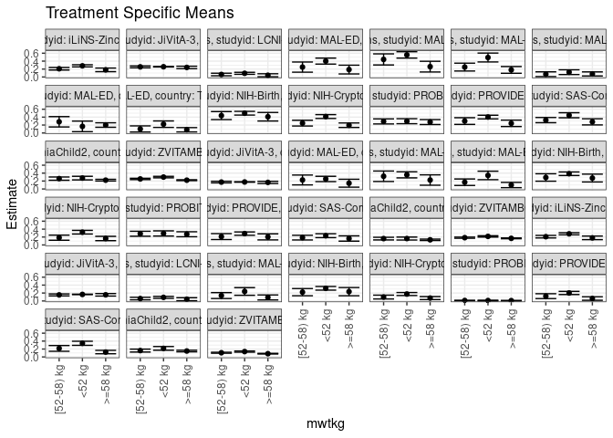

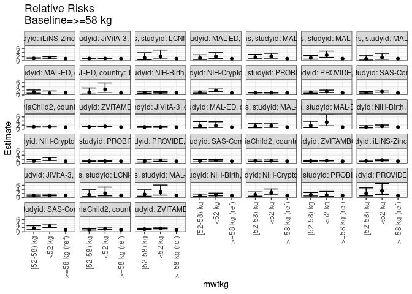

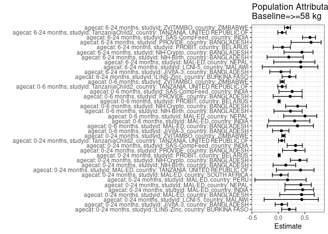

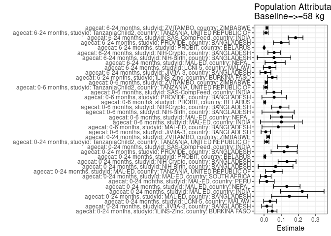

## Results Table

### Parameter: TSM

| agecat | studyid | country | intervention_level | baseline_level | estimate | ci_lower | ci_upper |
| --- | --- | --- | --- | --- | --- | --- | --- |
| 0-24 months | iLiNS-Zinc | BURKINA FASO | >=58 kg | NA | 0.1804536 | 0.1346359 | 0.2262712 |
| 0-24 months | iLiNS-Zinc | BURKINA FASO | <52 kg | NA | 0.2817452 | 0.2546668 | 0.3088236 |
| 0-24 months | iLiNS-Zinc | BURKINA FASO | [52-58) kg | NA | 0.2080507 | 0.1758023 | 0.2402992 |
| 0-24 months | JiVitA-3 | BANGLADESH | >=58 kg | NA | 0.2412258 | 0.2108214 | 0.2716302 |
| 0-24 months | JiVitA-3 | BANGLADESH | <52 kg | NA | 0.2585829 | 0.2519854 | 0.2651804 |
| 0-24 months | JiVitA-3 | BANGLADESH | [52-58) kg | NA | 0.2560655 | 0.2329546 | 0.2791765 |
| 0-24 months | LCNI-5 | MALAWI | >=58 kg | NA | 0.0438596 | 0.0062458 | 0.0814735 |
| 0-24 months | LCNI-5 | MALAWI | <52 kg | NA | 0.0932540 | 0.0678519 | 0.1186560 |
| 0-24 months | LCNI-5 | MALAWI | [52-58) kg | NA | 0.0636364 | 0.0313610 | 0.0959117 |
| 0-24 months | MAL-ED | BANGLADESH | >=58 kg | NA | 0.1875000 | 0.0768640 | 0.2981360 |
| 0-24 months | MAL-ED | BANGLADESH | <52 kg | NA | 0.4012346 | 0.3256079 | 0.4768612 |
| 0-24 months | MAL-ED | BANGLADESH | [52-58) kg | NA | 0.2500000 | 0.1218027 | 0.3781973 |
| 0-24 months | MAL-ED | INDIA | >=58 kg | NA | 0.2615063 | 0.1264981 | 0.3965145 |
| 0-24 months | MAL-ED | INDIA | <52 kg | NA | 0.5575892 | 0.4772611 | 0.6379172 |
| 0-24 months | MAL-ED | INDIA | [52-58) kg | NA | 0.4432977 | 0.3033727 | 0.5832227 |
| 0-24 months | MAL-ED | NEPAL | >=58 kg | NA | 0.1785978 | 0.0934927 | 0.2637028 |
| 0-24 months | MAL-ED | NEPAL | <52 kg | NA | 0.4918406 | 0.3797031 | 0.6039781 |
| 0-24 months | MAL-ED | NEPAL | [52-58) kg | NA | 0.2498899 | 0.1510997 | 0.3486802 |
| 0-24 months | MAL-ED | PERU | >=58 kg | NA | 0.0769231 | 0.0256217 | 0.1282244 |
| 0-24 months | MAL-ED | PERU | <52 kg | NA | 0.1217391 | 0.0618737 | 0.1816046 |
| 0-24 months | MAL-ED | PERU | [52-58) kg | NA | 0.0704225 | 0.0108059 | 0.1300392 |
| 0-24 months | MAL-ED | SOUTH AFRICA | >=58 kg | NA | 0.2010309 | 0.1445308 | 0.2575311 |
| 0-24 months | MAL-ED | SOUTH AFRICA | <52 kg | NA | 0.1666667 | 0.0330604 | 0.3002730 |
| 0-24 months | MAL-ED | SOUTH AFRICA | [52-58) kg | NA | 0.2826087 | 0.1522483 | 0.4129691 |
| 0-24 months | MAL-ED | TANZANIA, UNITED REPUBLIC OF | >=58 kg | NA | 0.0816327 | 0.0273170 | 0.1359483 |
| 0-24 months | MAL-ED | TANZANIA, UNITED REPUBLIC OF | <52 kg | NA | 0.2222222 | 0.1401678 | 0.3042766 |
| 0-24 months | MAL-ED | TANZANIA, UNITED REPUBLIC OF | [52-58) kg | NA | 0.1016949 | 0.0244209 | 0.1789689 |
| 0-24 months | NIH-Birth | BANGLADESH | >=58 kg | NA | 0.4104755 | 0.3025205 | 0.5184305 |
| 0-24 months | NIH-Birth | BANGLADESH | <52 kg | NA | 0.4991239 | 0.4527750 | 0.5454728 |
| 0-24 months | NIH-Birth | BANGLADESH | [52-58) kg | NA | 0.4392338 | 0.3381606 | 0.5403070 |

[output cut: 84 more lines]

### Parameter: E(Y)

| agecat | studyid | country | intervention_level | baseline_level | estimate | ci_lower | ci_upper |
| --- | --- | --- | --- | --- | --- | --- | --- |
| 0-24 months | iLiNS-Zinc | BURKINA FASO | NA | NA | 0.2278520 | 0.2008644 | 0.2548397 |
| 0-24 months | JiVitA-3 | BANGLADESH | NA | NA | 0.2580130 | 0.2515531 | 0.2644729 |
| 0-24 months | LCNI-5 | MALAWI | NA | NA | 0.0787589 | 0.0605107 | 0.0970072 |
| 0-24 months | MAL-ED | BANGLADESH | NA | NA | 0.3346457 | 0.2765014 | 0.3927899 |
| 0-24 months | MAL-ED | INDIA | NA | NA | 0.4834711 | 0.4203794 | 0.5465628 |
| 0-24 months | MAL-ED | NEPAL | NA | NA | 0.3109244 | 0.2519946 | 0.3698541 |
| 0-24 months | MAL-ED | PERU | NA | NA | 0.0931034 | 0.0596022 | 0.1266047 |
| 0-24 months | MAL-ED | SOUTH AFRICA | NA | NA | 0.2111111 | 0.1623431 | 0.2598792 |
| 0-24 months | MAL-ED | TANZANIA, UNITED REPUBLIC OF | NA | NA | 0.1406250 | 0.0979572 | 0.1832928 |
| 0-24 months | NIH-Birth | BANGLADESH | NA | NA | 0.4775641 | 0.4383415 | 0.5167867 |
| 0-24 months | NIH-Crypto | BANGLADESH | NA | NA | 0.3298013 | 0.2962438 | 0.3633589 |
| 0-24 months | PROBIT | BELARUS | NA | NA | 0.2805693 | 0.2183906 | 0.3427479 |
| 0-24 months | PROVIDE | BANGLADESH | NA | NA | 0.3602392 | 0.3238339 | 0.3966444 |
| 0-24 months | SAS-CompFeed | INDIA | NA | NA | 0.4172230 | 0.3585449 | 0.4759011 |
| 0-24 months | TanzaniaChild2 | TANZANIA, UNITED REPUBLIC OF | NA | NA | 0.2372449 | 0.2200495 | 0.2544403 |
| 0-24 months | ZVITAMBO | ZIMBABWE | NA | NA | 0.2457915 | 0.2378059 | 0.2537772 |
| 0-6 months | JiVitA-3 | BANGLADESH | NA | NA | 0.1761965 | 0.1705789 | 0.1818141 |
| 0-6 months | MAL-ED | BANGLADESH | NA | NA | 0.2283465 | 0.1766220 | 0.2800709 |
| 0-6 months | MAL-ED | INDIA | NA | NA | 0.3264463 | 0.2672449 | 0.3856476 |
| 0-6 months | MAL-ED | NEPAL | NA | NA | 0.2016807 | 0.1505956 | 0.2527658 |
| 0-6 months | NIH-Birth | BANGLADESH | NA | NA | 0.3569132 | 0.3192325 | 0.3945938 |
| 0-6 months | NIH-Crypto | BANGLADESH | NA | NA | 0.2569536 | 0.2257649 | 0.2881424 |
| 0-6 months | PROBIT | BELARUS | NA | NA | 0.2747604 | 0.2123223 | 0.3371985 |
| 0-6 months | PROVIDE | BANGLADESH | NA | NA | 0.2630792 | 0.2296894 | 0.2964690 |
| 0-6 months | SAS-CompFeed | INDIA | NA | NA | 0.2206573 | 0.1756202 | 0.2656944 |
| 0-6 months | TanzaniaChild2 | TANZANIA, UNITED REPUBLIC OF | NA | NA | 0.1403061 | 0.1262673 | 0.1543450 |
| 0-6 months | ZVITAMBO | ZIMBABWE | NA | NA | 0.1804281 | 0.1732799 | 0.1875764 |
| 6-24 months | iLiNS-Zinc | BURKINA FASO | NA | NA | 0.2278520 | 0.2008644 | 0.2548397 |
| 6-24 months | JiVitA-3 | BANGLADESH | NA | NA | 0.1638709 | 0.1577615 | 0.1699803 |
| 6-24 months | LCNI-5 | MALAWI | NA | NA | 0.0764563 | 0.0583018 | 0.0946108 |
| 6-24 months | MAL-ED | NEPAL | NA | NA | 0.1531915 | 0.1070438 | 0.1993392 |
| 6-24 months | NIH-Birth | BANGLADESH | NA | NA | 0.2933579 | 0.2549918 | 0.3317241 |
| 6-24 months | NIH-Crypto | BANGLADESH | NA | NA | 0.1315068 | 0.1069744 | 0.1560393 |
| 6-24 months | PROBIT | BELARUS | NA | NA | 0.0090817 | 0.0046144 | 0.0135489 |
| 6-24 months | PROVIDE | BANGLADESH | NA | NA | 0.1612378 | 0.1321259 | 0.1903497 |
| 6-24 months | SAS-CompFeed | INDIA | NA | NA | 0.3060781 | 0.2622443 | 0.3499120 |
| 6-24 months | TanzaniaChild2 | TANZANIA, UNITED REPUBLIC OF | NA | NA | 0.1612740 | 0.1450620 | 0.1774860 |
| 6-24 months | ZVITAMBO | ZIMBABWE | NA | NA | 0.0995484 | 0.0936035 | 0.1054934 |

### Parameter: RR

| agecat | studyid | country | intervention_level | baseline_level | estimate | ci_lower | ci_upper |
| --- | --- | --- | --- | --- | --- | --- | --- |
| 0-24 months | iLiNS-Zinc | BURKINA FASO | >=58 kg | >=58 kg | 1.0000000 | 1.0000000 | 1.000000 |
| 0-24 months | iLiNS-Zinc | BURKINA FASO | <52 kg | >=58 kg | 1.5613171 | 1.2220374 | 1.994792 |
| 0-24 months | iLiNS-Zinc | BURKINA FASO | [52-58) kg | >=58 kg | 1.1529323 | 0.9130251 | 1.455878 |
| 0-24 months | JiVitA-3 | BANGLADESH | >=58 kg | >=58 kg | 1.0000000 | 1.0000000 | 1.000000 |
| 0-24 months | JiVitA-3 | BANGLADESH | <52 kg | >=58 kg | 1.0719538 | 0.9426830 | 1.218952 |
| 0-24 months | JiVitA-3 | BANGLADESH | [52-58) kg | >=58 kg | 1.0615179 | 0.9050978 | 1.244971 |
| 0-24 months | LCNI-5 | MALAWI | >=58 kg | >=58 kg | 1.0000000 | 1.0000000 | 1.000000 |
| 0-24 months | LCNI-5 | MALAWI | <52 kg | >=58 kg | 2.1261905 | 0.8646020 | 5.228632 |
| 0-24 months | LCNI-5 | MALAWI | [52-58) kg | >=58 kg | 1.4509091 | 0.5357128 | 3.929600 |
| 0-24 months | MAL-ED | BANGLADESH | >=58 kg | >=58 kg | 1.0000000 | 1.0000000 | 1.000000 |
| 0-24 months | MAL-ED | BANGLADESH | <52 kg | >=58 kg | 2.1399177 | 1.1518112 | 3.975693 |
| 0-24 months | MAL-ED | BANGLADESH | [52-58) kg | >=58 kg | 1.3333333 | 0.6101437 | 2.913704 |
| 0-24 months | MAL-ED | INDIA | >=58 kg | >=58 kg | 1.0000000 | 1.0000000 | 1.000000 |
| 0-24 months | MAL-ED | INDIA | <52 kg | >=58 kg | 2.1322206 | 1.2470564 | 3.645677 |
| 0-24 months | MAL-ED | INDIA | [52-58) kg | >=58 kg | 1.6951701 | 0.9259160 | 3.103523 |
| 0-24 months | MAL-ED | NEPAL | >=58 kg | >=58 kg | 1.0000000 | 1.0000000 | 1.000000 |
| 0-24 months | MAL-ED | NEPAL | <52 kg | >=58 kg | 2.7539008 | 1.6276363 | 4.659499 |
| 0-24 months | MAL-ED | NEPAL | [52-58) kg | >=58 kg | 1.3991771 | 0.7517823 | 2.604074 |
| 0-24 months | MAL-ED | PERU | >=58 kg | >=58 kg | 1.0000000 | 1.0000000 | 1.000000 |
| 0-24 months | MAL-ED | PERU | <52 kg | >=58 kg | 1.5826087 | 0.6910535 | 3.624394 |
| 0-24 months | MAL-ED | PERU | [52-58) kg | >=58 kg | 0.9154930 | 0.3116133 | 2.689640 |
| 0-24 months | MAL-ED | SOUTH AFRICA | >=58 kg | >=58 kg | 1.0000000 | 1.0000000 | 1.000000 |
| 0-24 months | MAL-ED | SOUTH AFRICA | <52 kg | >=58 kg | 0.8290598 | 0.3545375 | 1.938695 |
| 0-24 months | MAL-ED | SOUTH AFRICA | [52-58) kg | >=58 kg | 1.4057971 | 0.8191006 | 2.412726 |
| 0-24 months | MAL-ED | TANZANIA, UNITED REPUBLIC OF | >=58 kg | >=58 kg | 1.0000000 | 1.0000000 | 1.000000 |
| 0-24 months | MAL-ED | TANZANIA, UNITED REPUBLIC OF | <52 kg | >=58 kg | 2.7222222 | 1.2718747 | 5.826434 |
| 0-24 months | MAL-ED | TANZANIA, UNITED REPUBLIC OF | [52-58) kg | >=58 kg | 1.2457627 | 0.4537299 | 3.420371 |
| 0-24 months | NIH-Birth | BANGLADESH | >=58 kg | >=58 kg | 1.0000000 | 1.0000000 | 1.000000 |
| 0-24 months | NIH-Birth | BANGLADESH | <52 kg | >=58 kg | 1.2159652 | 0.9197902 | 1.607509 |
| 0-24 months | NIH-Birth | BANGLADESH | [52-58) kg | >=58 kg | 1.0700609 | 0.7546197 | 1.517361 |

[output cut: 84 more lines]

### Parameter: PAR

| agecat | studyid | country | intervention_level | baseline_level | estimate | ci_lower | ci_upper |
| --- | --- | --- | --- | --- | --- | --- | --- |
| 0-24 months | iLiNS-Zinc | BURKINA FASO | >=58 kg | NA | 0.0473985 | 0.0194352 | 0.0753618 |
| 0-24 months | JiVitA-3 | BANGLADESH | >=58 kg | NA | 0.0167872 | -0.0135560 | 0.0471304 |
| 0-24 months | LCNI-5 | MALAWI | >=58 kg | NA | 0.0348993 | -0.0020178 | 0.0718164 |
| 0-24 months | MAL-ED | BANGLADESH | >=58 kg | NA | 0.1471457 | 0.0422895 | 0.2520018 |
| 0-24 months | MAL-ED | INDIA | >=58 kg | NA | 0.2219648 | 0.0953705 | 0.3485590 |
| 0-24 months | MAL-ED | NEPAL | >=58 kg | NA | 0.1323266 | 0.0554230 | 0.2092302 |
| 0-24 months | MAL-ED | PERU | >=58 kg | NA | 0.0161804 | -0.0270227 | 0.0593834 |
| 0-24 months | MAL-ED | SOUTH AFRICA | >=58 kg | NA | 0.0100802 | -0.0212756 | 0.0414360 |
| 0-24 months | MAL-ED | TANZANIA, UNITED REPUBLIC OF | >=58 kg | NA | 0.0589923 | 0.0088725 | 0.1091122 |
| 0-24 months | NIH-Birth | BANGLADESH | >=58 kg | NA | 0.0670886 | -0.0338973 | 0.1680745 |
| 0-24 months | NIH-Crypto | BANGLADESH | >=58 kg | NA | 0.1338030 | 0.0816665 | 0.1859396 |
| 0-24 months | PROBIT | BELARUS | >=58 kg | NA | 0.0044234 | 0.0000460 | 0.0088008 |
| 0-24 months | PROVIDE | BANGLADESH | >=58 kg | NA | 0.1166443 | 0.0409440 | 0.1923446 |
| 0-24 months | SAS-CompFeed | INDIA | >=58 kg | NA | 0.1359501 | 0.0770541 | 0.1948461 |
| 0-24 months | TanzaniaChild2 | TANZANIA, UNITED REPUBLIC OF | >=58 kg | NA | 0.0149089 | 0.0013218 | 0.0284960 |
| 0-24 months | ZVITAMBO | ZIMBABWE | >=58 kg | NA | 0.0239297 | 0.0160731 | 0.0317863 |
| 0-6 months | JiVitA-3 | BANGLADESH | >=58 kg | NA | 0.0101829 | -0.0170307 | 0.0373964 |
| 0-6 months | MAL-ED | BANGLADESH | >=58 kg | NA | 0.0825131 | -0.0118328 | 0.1768591 |
| 0-6 months | MAL-ED | INDIA | >=58 kg | NA | 0.1007482 | -0.0207286 | 0.2222250 |
| 0-6 months | MAL-ED | NEPAL | >=58 kg | NA | 0.1016807 | 0.0381826 | 0.1651787 |
| 0-6 months | NIH-Birth | BANGLADESH | >=58 kg | NA | 0.0815912 | -0.0118802 | 0.1750626 |
| 0-6 months | NIH-Crypto | BANGLADESH | >=58 kg | NA | 0.0937180 | 0.0429495 | 0.1444866 |
| 0-6 months | PROBIT | BELARUS | >=58 kg | NA | 0.0038807 | -0.0009658 | 0.0087271 |
| 0-6 months | PROVIDE | BANGLADESH | >=58 kg | NA | 0.0587411 | -0.0121329 | 0.1296152 |
| 0-6 months | SAS-CompFeed | INDIA | >=58 kg | NA | 0.0575972 | 0.0126409 | 0.1025534 |
| 0-6 months | TanzaniaChild2 | TANZANIA, UNITED REPUBLIC OF | >=58 kg | NA | 0.0100922 | -0.0010233 | 0.0212076 |
| 0-6 months | ZVITAMBO | ZIMBABWE | >=58 kg | NA | 0.0133431 | 0.0062737 | 0.0204125 |
| 6-24 months | iLiNS-Zinc | BURKINA FASO | >=58 kg | NA | 0.0482111 | 0.0210630 | 0.0753591 |
| 6-24 months | JiVitA-3 | BANGLADESH | >=58 kg | NA | 0.0081708 | -0.0233074 | 0.0396491 |
| 6-24 months | LCNI-5 | MALAWI | >=58 kg | NA | 0.0325967 | -0.0041856 | 0.0693789 |
| 6-24 months | MAL-ED | NEPAL | >=58 kg | NA | 0.0645839 | 0.0060879 | 0.1230799 |
| 6-24 months | NIH-Birth | BANGLADESH | >=58 kg | NA | 0.0580607 | -0.0392297 | 0.1553511 |
| 6-24 months | NIH-Crypto | BANGLADESH | >=58 kg | NA | 0.0586734 | 0.0225417 | 0.0948051 |
| 6-24 months | PROBIT | BELARUS | >=58 kg | NA | 0.0007237 | -0.0005703 | 0.0020177 |
| 6-24 months | PROVIDE | BANGLADESH | >=58 kg | NA | 0.0998343 | 0.0543326 | 0.1453359 |
| 6-24 months | SAS-CompFeed | INDIA | >=58 kg | NA | 0.1833046 | 0.1406184 | 0.2259908 |
| 6-24 months | TanzaniaChild2 | TANZANIA, UNITED REPUBLIC OF | >=58 kg | NA | 0.0115999 | -0.0009901 | 0.0241900 |
| 6-24 months | ZVITAMBO | ZIMBABWE | >=58 kg | NA | 0.0174700 | 0.0115777 | 0.0233623 |

### Parameter: PAF

| agecat | studyid | country | intervention_level | baseline_level | estimate | ci_lower | ci_upper |
| --- | --- | --- | --- | --- | --- | --- | --- |
| 0-24 months | iLiNS-Zinc | BURKINA FASO | >=58 kg | NA | 0.2080231 | 0.0616987 | 0.3315287 |
| 0-24 months | JiVitA-3 | BANGLADESH | >=58 kg | NA | 0.0650633 | -0.0600903 | 0.1754414 |
| 0-24 months | LCNI-5 | MALAWI | >=58 kg | NA | 0.4431154 | -0.2685075 | 0.7555233 |
| 0-24 months | MAL-ED | BANGLADESH | >=58 kg | NA | 0.4397059 | 0.0269915 | 0.6773620 |
| 0-24 months | MAL-ED | INDIA | >=58 kg | NA | 0.4591066 | 0.1219956 | 0.6667834 |
| 0-24 months | MAL-ED | NEPAL | >=58 kg | NA | 0.4255909 | 0.1256396 | 0.6226432 |
| 0-24 months | MAL-ED | PERU | >=58 kg | NA | 0.1737892 | -0.4426530 | 0.5268271 |
| 0-24 months | MAL-ED | SOUTH AFRICA | >=58 kg | NA | 0.0477482 | -0.1127541 | 0.1850999 |
| 0-24 months | MAL-ED | TANZANIA, UNITED REPUBLIC OF | >=58 kg | NA | 0.4195011 | -0.0382341 | 0.6754307 |
| 0-24 months | NIH-Birth | BANGLADESH | >=58 kg | NA | 0.1404808 | -0.0995119 | 0.3280898 |
| 0-24 months | NIH-Crypto | BANGLADESH | >=58 kg | NA | 0.4057080 | 0.2278461 | 0.5426003 |
| 0-24 months | PROBIT | BELARUS | >=58 kg | NA | 0.0157657 | -0.0008228 | 0.0320793 |
| 0-24 months | PROVIDE | BANGLADESH | >=58 kg | NA | 0.3237969 | 0.0780815 | 0.5040228 |
| 0-24 months | SAS-CompFeed | INDIA | >=58 kg | NA | 0.3258453 | 0.1670730 | 0.4543524 |
| 0-24 months | TanzaniaChild2 | TANZANIA, UNITED REPUBLIC OF | >=58 kg | NA | 0.0628418 | 0.0038904 | 0.1183045 |
| 0-24 months | ZVITAMBO | ZIMBABWE | >=58 kg | NA | 0.0973579 | 0.0648973 | 0.1286915 |
| 0-6 months | JiVitA-3 | BANGLADESH | >=58 kg | NA | 0.0577926 | -0.1099800 | 0.2002065 |
| 0-6 months | MAL-ED | BANGLADESH | >=58 kg | NA | 0.3613506 | -0.2099737 | 0.6629075 |
| 0-6 months | MAL-ED | INDIA | >=58 kg | NA | 0.3086212 | -0.1832633 | 0.5960285 |
| 0-6 months | MAL-ED | NEPAL | >=58 kg | NA | 0.5041667 | 0.1014472 | 0.7263926 |
| 0-6 months | NIH-Birth | BANGLADESH | >=58 kg | NA | 0.2286024 | -0.0831137 | 0.4506077 |
| 0-6 months | NIH-Crypto | BANGLADESH | >=58 kg | NA | 0.3647274 | 0.1370478 | 0.5323365 |
| 0-6 months | PROBIT | BELARUS | >=58 kg | NA | 0.0141238 | -0.0043939 | 0.0323000 |
| 0-6 months | PROVIDE | BANGLADESH | >=58 kg | NA | 0.2232831 | -0.0979281 | 0.4505203 |
| 0-6 months | SAS-CompFeed | INDIA | >=58 kg | NA | 0.2610255 | 0.0104655 | 0.4481412 |
| 0-6 months | TanzaniaChild2 | TANZANIA, UNITED REPUBLIC OF | >=58 kg | NA | 0.0719296 | -0.0104846 | 0.1476221 |
| 0-6 months | ZVITAMBO | ZIMBABWE | >=58 kg | NA | 0.0739523 | 0.0340167 | 0.1122369 |
| 6-24 months | iLiNS-Zinc | BURKINA FASO | >=58 kg | NA | 0.2115893 | 0.0694351 | 0.3320279 |
| 6-24 months | JiVitA-3 | BANGLADESH | >=58 kg | NA | 0.0498615 | -0.1628723 | 0.2236781 |
| 6-24 months | LCNI-5 | MALAWI | >=58 kg | NA | 0.4263436 | -0.3046507 | 0.7477627 |
| 6-24 months | MAL-ED | NEPAL | >=58 kg | NA | 0.4215893 | -0.0867215 | 0.6921392 |
| 6-24 months | NIH-Birth | BANGLADESH | >=58 kg | NA | 0.1979176 | -0.2129696 | 0.4696188 |
| 6-24 months | NIH-Crypto | BANGLADESH | >=58 kg | NA | 0.4461624 | 0.1063699 | 0.6567528 |
| 6-24 months | PROBIT | BELARUS | >=58 kg | NA | 0.0796866 | -0.0979366 | 0.2285741 |
| 6-24 months | PROVIDE | BANGLADESH | >=58 kg | NA | 0.6191742 | 0.2410369 | 0.8089126 |
| 6-24 months | SAS-CompFeed | INDIA | >=58 kg | NA | 0.5988817 | 0.4579734 | 0.7031586 |
| 6-24 months | TanzaniaChild2 | TANZANIA, UNITED REPUBLIC OF | >=58 kg | NA | 0.0719269 | -0.0092815 | 0.1466013 |
| 6-24 months | ZVITAMBO | ZIMBABWE | >=58 kg | NA | 0.1754923 | 0.1149612 | 0.2318835 |